# House Prices: Advanced Regression Techniques

Cris Pineda and Diego Hernández

2/18/2018

Loading libraries:

```r
library(tidyverse)
library(caret)
library(glmnet)
library(e1071)
library(ModelMetrics)
library(Metrics)
library(factoextra)
library(dummies)
library(moments)
dyn.load('/Library/Java/JavaVirtualMachines/jdk-9.0.1.jdk/Contents/Home/lib/server/libjvm.dylib') # in order for FSelector to work
library(FSelector)
library(data.table)
library(xgboost)
library(Metrics)
library(Matrix)
library(mice)
library(elasticnet)
```

Loading training and testing data

```r
setwd("~/Desktop/Courses/Second Semester/Machine Learning II/Assignment 1")
trainingH = read.csv("train.csv")
testingH = read.csv("test.csv")
```

Splitting and saving the columns for later use

```r
# Save SalePrice for later
SalePrice <- trainingH[ , which(names(trainingH) %in% c("SalePrice"))]
# delete SalePrice
trainingH$SalePrice = NULL

# merge the two
all = rbind(trainingH, testingH)

levels(all$Utilities)
```

```
## [1] "AllPub" "NoSeWa"
```

```r
levels(testingH$Utilities)
```

```
## [1] "AllPub"
```

```r
# we will erase it cause there is only one different value
all$Utilities = NULL
```

Just for reference : train = Id(1-1460) test = Id(1461-2919)

** DATA CLEANING **

Check if we have duplicates values:

```r
length(unique(all$Id)) == nrow(all) # True
```

```
## [1] TRUE
```

No duplicates

Compute the number of NAs on each column:

```r
na.cols = which(colSums(is.na(all)) > 0)
sort(colSums(sapply(all[na.cols], is.na)), decreasing = TRUE)
```

```
##       PoolQC  MiscFeature        Alley        Fence  FireplaceQu
##         2909         2814         2721         2348         1420
##  LotFrontage  GarageYrBlt GarageFinish   GarageQual   GarageCond
##          486          159          159          159          159
##   GarageType     BsmtCond BsmtExposure     BsmtQual BsmtFinType2
##          157           82           82           81           80
## BsmtFinType1   MasVnrType   MasVnrArea     MSZoning BsmtFullBath
##           79           24           23            4            2
## BsmtHalfBath   Functional  Exterior1st  Exterior2nd   BsmtFinSF1
##            2            2            1            1            1
##   BsmtFinSF2    BsmtUnfSF  TotalBsmtSF   Electrical  KitchenQual
##            1            1            1            1            1
##   GarageCars   GarageArea     SaleType
##            1            1            1
```

```r
paste('There are', length(na.cols), 'columns with missing values')
```

```
## [1] "There are 33 columns with missing values"
```

There are 33 columns with NAs so we will analyze and fix these.

Let’s check the quality of the pool with its area and we found that we only have 10 values for quality. NAs for PoolQC can be filled with 0 and the the only 3 values with pool can be filled with the mean value of its group

```r
# check which have a pool but are NA
all[(all$PoolArea > 0) & is.na(all$PoolQC), c('PoolQC','PoolArea')]

# ge the mean and count for PoolArea
all %>%
  group_by(PoolQC) %>%
  select(PoolQC, PoolArea) %>%
  summarise(avg_poolarea = mean(PoolArea, na.rm = T), count = n())

# filter to see which are valid NAs
all %>%
  select(PoolQC, PoolArea) %>%
  filter(is.na(PoolQC & PoolArea > 0))
# impute the closest PoolQC to these
all[2421,'PoolQC'] = 'Ex'
all[2504,'PoolQC'] = 'Ex'
all[2600,'PoolQC'] = 'Fa'
```

For GarageYr and YearBuilt we can infer that the garage was built the same year that the house was built

```r
length(which(all$GarageYrBlt == all$YearBuilt)) # 2216/2919 have the same year
```

```
## [1] 2216
```

```r
idx = which(is.na(all$GarageYrBlt))
all[idx, 'GarageYrBlt'] = all[idx, 'YearBuilt']
```

We check the rest of the features related to the garage

```r
# group all the Garage variable to better analyze them
garage.cols = c('GarageArea', 'GarageCars', 'GarageQual', 'GarageFinish', 'GarageCond', 'GarageType')
all[is.na(all$GarageCond), garage.cols]
```

```
##      GarageArea GarageCars GarageQual GarageFinish GarageCond GarageType
## 40            0          0       <NA>         <NA>       <NA>       <NA>
## 49            0          0       <NA>         <NA>       <NA>       <NA>
## 79            0          0       <NA>         <NA>       <NA>       <NA>
## 89            0          0       <NA>         <NA>       <NA>       <NA>
## 90            0          0       <NA>         <NA>       <NA>       <NA>
## 100           0          0       <NA>         <NA>       <NA>       <NA>
## 109           0          0       <NA>         <NA>       <NA>       <NA>
## 126           0          0       <NA>         <NA>       <NA>       <NA>
## 128           0          0       <NA>         <NA>       <NA>       <NA>
## 141           0          0       <NA>         <NA>       <NA>       <NA>
## 149           0          0       <NA>         <NA>       <NA>       <NA>
## 156           0          0       <NA>         <NA>       <NA>       <NA>
## 164           0          0       <NA>         <NA>       <NA>       <NA>
## 166           0          0       <NA>         <NA>       <NA>       <NA>
```

[output cut: 145 more lines]

```r
idx = which(((all$GarageArea < 370) & (all$GarageArea > 350)) & (all$GarageCars == 1))

names(sapply(all[idx, garage.cols], function(x) sort(table(x), decreasing=TRUE)[1]))
```

```
## [1] "GarageArea.352"    "GarageCars.1"      "GarageQual.TA"
## [4] "GarageFinish.Unf"  "GarageCond.TA"     "GarageType.Attchd"
```

```r
# we fill NAs for the values it corresponds
all[2127,'GarageQual'] = 'TA'
all[2127, 'GarageFinish'] = 'Unf'
all[2127, 'GarageCond'] = 'TA'

# 2577 had NA instead of 0 but Semi-Det garage type with no info
all[2577, 'GarageArea'] = 0
all[2577, 'GarageCars'] = 0
all[2577, 'GarageType'] = "NA"
```

Let’s go for the KitchenQual:

```r
all %>%
  group_by(KitchenQual) %>%
  select(KitchenQual) %>%
  summarise(count = n())
```

```
## # A tibble: 5 x 2
##   KitchenQual count
##        <fctr> <int>
## 1          Ex   205
## 2          Fa    70
## 3          Gd  1151
## 4          TA  1492
## 5        <NA>     1
```

```r
# most common value is TA, we may fill NAs with this values
all$KitchenQual[is.na(all$KitchenQual)] = 'TA'
```

We will keep doing this with more predictors:

```r
all %>%
  group_by(Electrical) %>%
  select(Electrical) %>%
  summarise(count = n()) # SBrkr is the most common
```

```
## # A tibble: 6 x 2
##   Electrical count
##       <fctr> <int>
## 1      FuseA   188
## 2      FuseF    50
## 3      FuseP     8
## 4        Mix     1
## 5      SBrkr  2671
## 6       <NA>     1
```

```r
# impute most common
all$Electrical[is.na(all$Electrical)] = 'SBrkr'

all %>%
  group_by(Electrical) %>%
  select(Electrical) %>%
  summarise(count = n())
```

```
## # A tibble: 5 x 2
##   Electrical count
##       <fctr> <int>
## 1      FuseA   188
## 2      FuseF    50
## 3      FuseP     8
## 4        Mix     1
## 5      SBrkr  2672
```

```r
all %>%
  group_by(SaleCondition) %>%
  select(SaleCondition) %>%
  summarise(count = n()) # let's compare SaleCondition with SaleType as both seem to be related features
```

```
## # A tibble: 6 x 2
##   SaleCondition count
##          <fctr> <int>
## 1       Abnorml   190
## 2       AdjLand    12
## 3        Alloca    24
## 4        Family    46
## 5        Normal  2402
## 6       Partial   245
```

```r
table(all$SaleCondition, all$SaleType) # most of the Normal(SaleCondition) house have WD as SaleType
```

```
##
##            COD  Con ConLD ConLI ConLw  CWD  New  Oth   WD
##   Abnorml   46    0     3     2     0    1    0    5  133
##   AdjLand    0    0     0     0     0    0    0    0   12
##   Alloca     0    0     0     0     0    0    0    0   24
##   Family     2    0     1     2     1    1    0    1   38
##   Normal    39    4    21     5     7   10    0    1 2314
##   Partial    0    1     1     0     0    0  239    0    4
```

```r
all$SaleType[is.na(all$SaleType)] = 'WD'

all %>%
  group_by(Functional) %>%
  select(Functional) %>%
  summarise(count = n())
```

```
## # A tibble: 8 x 2
##   Functional count
##       <fctr> <int>
## 1       Maj1    19
## 2       Maj2     9
## 3       Min1    65
## 4       Min2    70
## 5        Mod    35
## 6        Sev     2
## 7        Typ  2717
## 8       <NA>     2
```

```r
# impute for NA
all$Functional[is.na(all$Functional)] = 'Typ'


all %>%
  group_by(MSZoning) %>%
  select(MSZoning) %>%
  summarise(count = n()) # RL
```

```
## # A tibble: 6 x 2
##   MSZoning count
##     <fctr> <int>
## 1  C (all)    25
## 2       FV   139
## 3       RH    26
## 4       RL  2265
## 5       RM   460
## 6     <NA>     4
```

```r
# impute most common
all$MSZoning[is.na(all$MSZoning)] = 'RL'
```

Let’s look at LotFrontage

```r
# view how many neighborhoods
levels(all$Neighborhood)
```

```
##  [1] "Blmngtn" "Blueste" "BrDale"  "BrkSide" "ClearCr" "CollgCr" "Crawfor"
##  [8] "Edwards" "Gilbert" "IDOTRR"  "MeadowV" "Mitchel" "NAmes"   "NoRidge"
## [15] "NPkVill" "NridgHt" "NWAmes"  "OldTown" "Sawyer"  "SawyerW" "Somerst"
## [22] "StoneBr" "SWISU"   "Timber"  "Veenker"
```

```r
# get median for Neighborhood
all %>%
  group_by(Neighborhood) %>%
    summarise(median_lotFRont = median(LotFrontage, na.rm = T))
```

```
## # A tibble: 25 x 2
##    Neighborhood median_lotFRont
##          <fctr>           <dbl>
##  1      Blmngtn            43.0
##  2      Blueste            24.0
##  3       BrDale            21.0
##  4      BrkSide            51.0
##  5      ClearCr            80.5
##  6      CollgCr            70.0
##  7      Crawfor            70.0
##  8      Edwards            65.0
##  9      Gilbert            64.0
## 10       IDOTRR            60.0
## # ... with 15 more rows
```

```r
# replace NA with the median
all$LotFrontage = with(all, ave(LotFrontage, Neighborhood,
    FUN = function(x) replace(x, is.na(x), median(x, na.rm = TRUE))))
```

Change some of the NAs with other values

```r
moreNAs <- which(colSums(is.na(all)) > 0)
sort(colSums(sapply(all[moreNAs], is.na)), decreasing = TRUE)
```

```
##       PoolQC  MiscFeature        Alley        Fence  FireplaceQu
##         2906         2814         2721         2348         1420
##   GarageType GarageFinish   GarageQual   GarageCond     BsmtCond
##          158          158          158          158           82
## BsmtExposure     BsmtQual BsmtFinType2 BsmtFinType1   MasVnrType
##           82           81           80           79           24
##   MasVnrArea BsmtFullBath BsmtHalfBath  Exterior1st  Exterior2nd
##           23            2            2            1            1
##   BsmtFinSF1   BsmtFinSF2    BsmtUnfSF  TotalBsmtSF
##            1            1            1            1
```

```r
paste('There are', length(moreNAs), 'columns with missing values')
```

```
## [1] "There are 24 columns with missing values"
```

There are still 24 columns with NAs

Dealing with the rest of the NAs USE THIS AS REFERENCE TO CONSTANTLY CHECK: sort(colSums(sapply(all[moreNAs], is.na)), decreasing = TRUE)

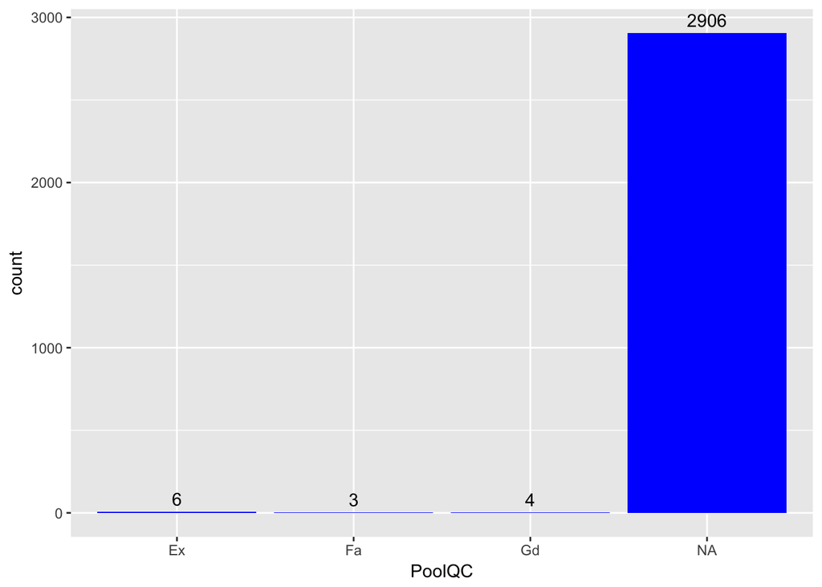

```r
## use this as reference and adjust X axis for each variable
ggplot(data = all, aes(x = PoolQC)) +
  geom_bar(fill = 'blue') +
  geom_text(aes(label = ..count..), stat='count', vjust=-0.5)
```

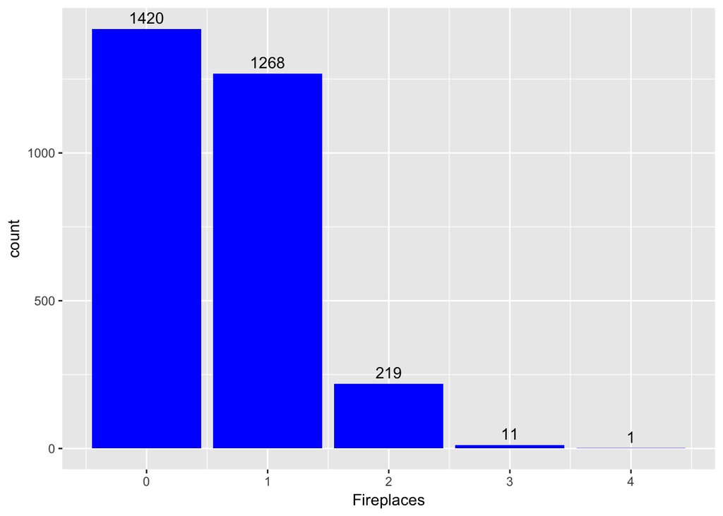

```r
# Pool QC
all$PoolQC = factor(all$PoolQC, levels=c(levels(all$PoolQC), "None"))
all$PoolQC[is.na(all$PoolQC)] = "None"

# MiscFeature
all$MiscFeature = factor(all$MiscFeature, levels=c(levels(all$MiscFeature), "None"))
all$MiscFeature[is.na(all$MiscFeature)] = "None"

# Alley

all$Alley = factor(all$Alley, levels=c(levels(all$Alley), "None"))
all$Alley[is.na(all$Alley)] = "None"

# Fence
all$Fence = factor(all$Fence, levels=c(levels(all$Fence), "None"))
all$Fence[is.na(all$Fence)] = "None"

# FireplaceQu
## 1420 NAs
# see how many fireplaces are 0 and see if matches NAs
ggplot(data = all, aes(x = Fireplaces)) +
  geom_bar(fill = 'blue') +
  geom_text(aes(label = ..count..), stat='count', vjust=-0.5) # they match
```

```r
all$FireplaceQu = factor(all$FireplaceQu, levels=c(levels(all$FireplaceQu), "None"))
all$FireplaceQu[is.na(all$FireplaceQu)] = "None"
```

Dealing with the NAs for all the variables related to Garage

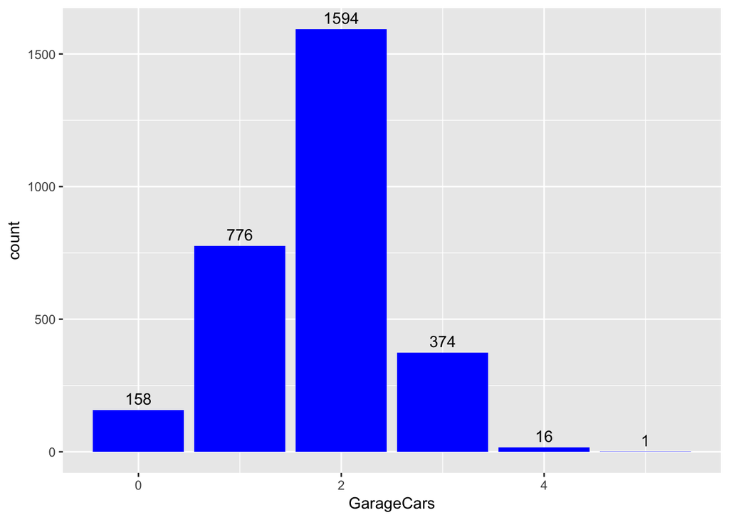

```r
# Garages : NA for garage features is "no garage"
## first lets make sure the 158 matches 0 car garages
ggplot(data = all, aes(x = GarageCars)) +
  geom_bar(fill = 'blue') +
  geom_text(aes(label = ..count..), stat='count', vjust=-0.5) # they match
```

```r
# GarageType
all$GarageType = factor(all$GarageType, levels=c(levels(all$GarageType), "None"))
all$GarageType[is.na(all$GarageType)] = "None"
# GarageFinish
all$GarageFinish = factor(all$GarageFinish, levels=c(levels(all$GarageFinish), "None"))
all$GarageFinish[is.na(all$GarageFinish)] = "None"
# GarageQual
all$GarageQual = factor(all$GarageQual, levels=c(levels(all$GarageQual), "None"))
all$GarageQual[is.na(all$GarageQual)] = "None"
# GarageCond
all$GarageCond = factor(all$GarageCond, levels=c(levels(all$GarageCond), "None"))
all$GarageCond[is.na(all$GarageCond)] = "None"
```

Next for Basement variables

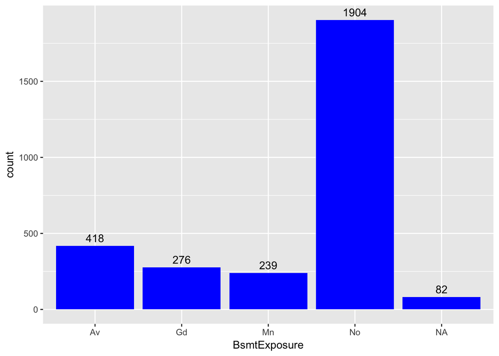

```r
# Basements
## function to group basements
bsmt.cols <- names(all)[sapply(names(all), function(x) str_detect(x, 'Bsmt'))]

# BsmtExposure
ggplot(data = all, aes(x = BsmtExposure)) +
  geom_bar(fill = 'blue') +
  geom_text(aes(label = ..count..), stat='count', vjust=-0.5)
```

```r
all[is.na(all$BsmtExposure),bsmt.cols] #949, 1488, 2349
```

```
##      BsmtQual BsmtCond BsmtExposure BsmtFinType1 BsmtFinSF1 BsmtFinType2
## 18       <NA>     <NA>         <NA>         <NA>          0         <NA>
## 40       <NA>     <NA>         <NA>         <NA>          0         <NA>
## 91       <NA>     <NA>         <NA>         <NA>          0         <NA>
## 103      <NA>     <NA>         <NA>         <NA>          0         <NA>
## 157      <NA>     <NA>         <NA>         <NA>          0         <NA>
## 183      <NA>     <NA>         <NA>         <NA>          0         <NA>
## 260      <NA>     <NA>         <NA>         <NA>          0         <NA>
## 343      <NA>     <NA>         <NA>         <NA>          0         <NA>
## 363      <NA>     <NA>         <NA>         <NA>          0         <NA>
## 372      <NA>     <NA>         <NA>         <NA>          0         <NA>
## 393      <NA>     <NA>         <NA>         <NA>          0         <NA>
## 521      <NA>     <NA>         <NA>         <NA>          0         <NA>
## 533      <NA>     <NA>         <NA>         <NA>          0         <NA>
## 534      <NA>     <NA>         <NA>         <NA>          0         <NA>
```

[output cut: 151 more lines]

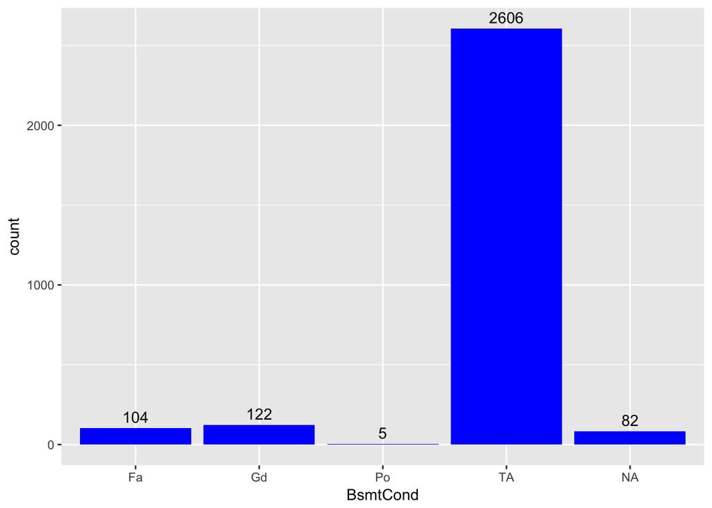

```r
# we fill NAs with most common that actually have garages
all[949,'BsmtExposure'] = 'No'
all[1488, 'BsmtExposure'] = 'No'
all[2349, 'BsmtExposure'] = 'No'
# now fill with None
all$BsmtExposure = factor(all$BsmtExposure, levels=c(levels(all$BsmtExposure), "None"))
all$BsmtExposure[is.na(all$BsmtExposure)] = "None"

# BsmtCond
ggplot(data = all, aes(x = BsmtCond)) +
  geom_bar(fill = 'blue') +
  geom_text(aes(label = ..count..), stat='count', vjust=-0.5)
```

```r
all[is.na(all$BsmtCond),bsmt.cols] # 2041, 2186, 2525
```

```
##      BsmtQual BsmtCond BsmtExposure BsmtFinType1 BsmtFinSF1 BsmtFinType2
## 18       <NA>     <NA>         None         <NA>          0         <NA>
## 40       <NA>     <NA>         None         <NA>          0         <NA>
## 91       <NA>     <NA>         None         <NA>          0         <NA>
## 103      <NA>     <NA>         None         <NA>          0         <NA>
## 157      <NA>     <NA>         None         <NA>          0         <NA>
## 183      <NA>     <NA>         None         <NA>          0         <NA>
## 260      <NA>     <NA>         None         <NA>          0         <NA>
## 343      <NA>     <NA>         None         <NA>          0         <NA>
## 363      <NA>     <NA>         None         <NA>          0         <NA>
## 372      <NA>     <NA>         None         <NA>          0         <NA>
## 393      <NA>     <NA>         None         <NA>          0         <NA>
## 521      <NA>     <NA>         None         <NA>          0         <NA>
## 533      <NA>     <NA>         None         <NA>          0         <NA>
## 534      <NA>     <NA>         None         <NA>          0         <NA>
```

[output cut: 151 more lines]

```r
# these have basements, fill with most common
all[2041,'BsmtCond'] = 'TA'
all[2186, 'BsmtCond'] = 'TA'
all[2525, 'BsmtCond'] = 'TA'
# now fill NA with none
all$BsmtCond = factor(all$BsmtCond, levels=c(levels(all$BsmtCond), "None"))
all$BsmtCond[is.na(all$BsmtCond)] = "None"

# BsmtQual
## 2218 & 2219 do have basements so putting it same as BsmtCond
all[2218,'BsmtQual'] = 'Fa'
all[2219, 'BsmtQual'] = 'TA'
# now fix NAs
all$BsmtQual = factor(all$BsmtQual, levels=c(levels(all$BsmtQual), "None"))
all$BsmtQual[is.na(all$BsmtQual)] = "None"

# BsmtFinType2
## 333 should not be NA, just make it same as BsmtFinType1
all[333,'BsmtFinType2'] = 'GLQ'
# now fill NA with none
all$BsmtFinType2 = factor(all$BsmtFinType2, levels=c(levels(all$BsmtFinType2), "None"))
all$BsmtFinType2[is.na(all$BsmtFinType2)] = "None"

# BsmtFinType1 is good to change to none
all$BsmtFinType1 = factor(all$BsmtFinType1, levels=c(levels(all$BsmtFinType1), "None"))
all$BsmtFinType1[is.na(all$BsmtFinType1)] = "None"

# BsmtExposure
## most are No so just change it
all$BsmtExposure[is.na(all$BsmtExposure)] = "No"

# BsmtFullBath & Half Bath just need 0
all$BsmtFullBath[is.na(all$BsmtFullBath)] <- 0
all$BsmtHalfBath[is.na(all$BsmtHalfBath)] <- 0

# BsmtFinSF1, BsmtFinSF2,TotalBsmtSF, BsmtUnfSF
## row 2121 has no basment so can impute o for each
all[2121,'BsmtFinSF1'] = 0
all[2121,'BsmtFinSF2'] = 0
all[2121,'TotalBsmtSF'] = 0
all[2121,'BsmtUnfSF'] = 0
```

We used: “sort(colSums(sapply(all[moreNAs], is.na)), decreasing = TRUE)” and “View(all[is.na(all$BsmtExposure),bsmt.cols])” to analyze each variable and manually fix errors between NAs that should be NA and not

Finish off the NAs

```r
# Exterior1st & Exterior2nd
all[is.na(all$Exterior1st),] # row 2152 only one
```

```
##        Id MSSubClass MSZoning LotFrontage LotArea Street Alley LotShape
## 2152 2152         30       RL          85   19550   Pave  None      Reg
##      LandContour LotConfig LandSlope Neighborhood Condition1 Condition2
## 2152         Lvl    Inside       Gtl      Edwards       Norm       Norm
##      BldgType HouseStyle OverallQual OverallCond YearBuilt YearRemodAdd
## 2152     1Fam     1Story           5           7      1940         2007
##      RoofStyle RoofMatl Exterior1st Exterior2nd MasVnrType MasVnrArea
## 2152      Flat  Tar&Grv        <NA>        <NA>       None          0
##      ExterQual ExterCond Foundation BsmtQual BsmtCond BsmtExposure
## 2152        TA        TA      PConc       TA       TA           Gd
##      BsmtFinType1 BsmtFinSF1 BsmtFinType2 BsmtFinSF2 BsmtUnfSF TotalBsmtSF
## 2152          ALQ       1035          Unf          0       545        1580
##      Heating HeatingQC CentralAir Electrical X1stFlrSF X2ndFlrSF
## 2152    GasA        Ex          Y      SBrkr      1518         0
##      LowQualFinSF GrLivArea BsmtFullBath BsmtHalfBath FullBath HalfBath
## 2152            0      1518            1            0        1        0
##      BedroomAbvGr KitchenAbvGr KitchenQual TotRmsAbvGrd Functional
## 2152            2            1          Fa            5        Typ
##      Fireplaces FireplaceQu GarageType GarageYrBlt GarageFinish GarageCars
## 2152          2          Gd       None        1940         None          0
##      GarageArea GarageQual GarageCond PavedDrive WoodDeckSF OpenPorchSF
## 2152          0       None       None          Y          0          39
##      EnclosedPorch X3SsnPorch ScreenPorch PoolArea PoolQC Fence
## 2152             0          0           0        0   None  None
##      MiscFeature MiscVal MoSold YrSold SaleType SaleCondition
## 2152        None       0      1   2008       WD        Normal
```

```r
levels(all$Exterior1st)
```

```
##  [1] "AsbShng" "AsphShn" "BrkComm" "BrkFace" "CBlock"  "CemntBd" "HdBoard"
##  [8] "ImStucc" "MetalSd" "Plywood" "Stone"   "Stucco"  "VinylSd" "Wd Sdng"
## [15] "WdShing"
```

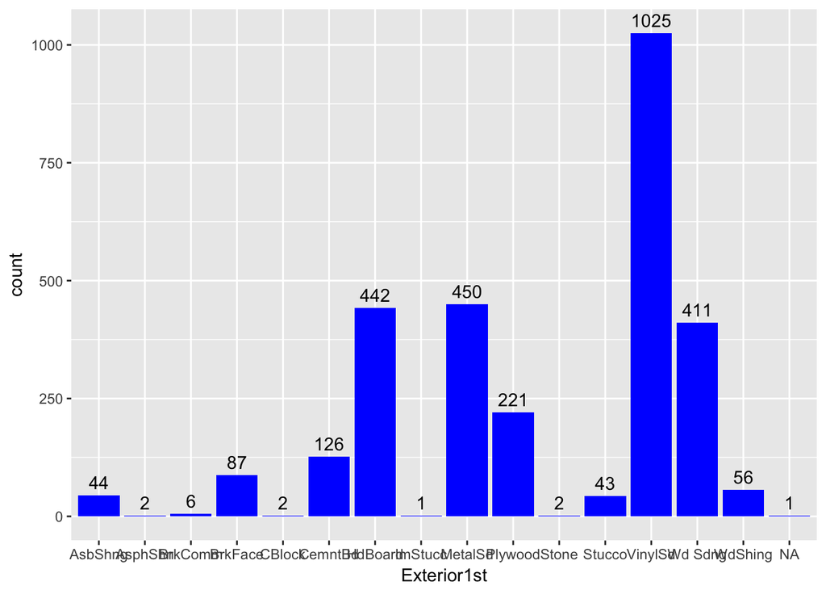

```r
# plot
ggplot(data = all, aes(x = Exterior1st)) +
  geom_bar(fill = 'blue') +
  geom_text(aes(label = ..count..), stat='count', vjust=-0.5)
```

```r
# change to VinylSd for now since it is most common
all$Exterior1st[is.na(all$Exterior1st)] = "VinylSd"
# also for Exterior2nd
all$Exterior2nd[is.na(all$Exterior2nd)] = "VinylSd"

# MasVnrType & MasVnrArea
MasVnr.cols <- names(all)[sapply(names(all), function(x) str_detect(x, 'MasVnr'))]
all[is.na(all$MasVnrType),MasVnr.cols]
```

```
##      MasVnrType MasVnrArea
## 235        <NA>         NA
## 530        <NA>         NA
## 651        <NA>         NA
## 937        <NA>         NA
## 974        <NA>         NA
## 978        <NA>         NA
## 1244       <NA>         NA
## 1279       <NA>         NA
## 1692       <NA>         NA
## 1707       <NA>         NA
## 1883       <NA>         NA
## 1993       <NA>         NA
## 2005       <NA>         NA
## 2042       <NA>         NA
## 2312       <NA>         NA
## 2326       <NA>         NA
## 2341       <NA>         NA
## 2350       <NA>         NA
## 2369       <NA>         NA
## 2593       <NA>         NA
## 2611       <NA>        198
## 2658       <NA>         NA
## 2687       <NA>         NA
## 2863       <NA>         NA
```

```r
# put most used
all[2611, 'MasVnrType'] = 'BrkFace'
# change to MasVnrType
all$MasVnrType[is.na(all$MasVnrType)] = "None"
# also for MasVnrArea
all$MasVnrArea[is.na(all$MasVnrArea)] = 0
```

We will change CentralAir manually since it should be binary

```r
## manually change CentralAir to avoid making excessive
all <- all %>%
  mutate(CentralAir = ifelse(CentralAir == "Y", 1, 0))
```

Here we will apply one-hot encoding for every non numeric variable, first we will get those variables and then we will make use of the caret package

```r
type_of_vars = sapply(names(all), function(x){class(all[[x]])})
numeric_vars = names(type_of_vars[type_of_vars == "integer"])
categorical_vars = names(type_of_vars[type_of_vars != "integer"])

dummies = dummyVars(~.,all[categorical_vars])
categorical_1_hot = predict(dummies,all[categorical_vars])
categorical_1_hot[is.na(categorical_1_hot)] = 0
```

Now lets convert all numericals that should be categorial to avoid any skewing we might do

```r
# take a look and see which ones should be changed
glimpse(all)
```

```
## Observations: 2,919
## Variables: 79
## $ Id            <int> 1, 2, 3, 4, 5, 6, 7, 8, 9, 10, 11, 12, 13, 14, 1...
## $ MSSubClass    <int> 60, 20, 60, 70, 60, 50, 20, 60, 50, 190, 20, 60,...
## $ MSZoning      <fctr> RL, RL, RL, RL, RL, RL, RL, RL, RM, RL, RL, RL,...
## $ LotFrontage   <dbl> 65, 80, 68, 60, 84, 85, 75, 80, 51, 50, 70, 85, ...
## $ LotArea       <int> 8450, 9600, 11250, 9550, 14260, 14115, 10084, 10...
## $ Street        <fctr> Pave, Pave, Pave, Pave, Pave, Pave, Pave, Pave,...
## $ Alley         <fctr> None, None, None, None, None, None, None, None,...
## $ LotShape      <fctr> Reg, Reg, IR1, IR1, IR1, IR1, Reg, IR1, Reg, Re...
## $ LandContour   <fctr> Lvl, Lvl, Lvl, Lvl, Lvl, Lvl, Lvl, Lvl, Lvl, Lv...
## $ LotConfig     <fctr> Inside, FR2, Inside, Corner, FR2, Inside, Insid...
## $ LandSlope     <fctr> Gtl, Gtl, Gtl, Gtl, Gtl, Gtl, Gtl, Gtl, Gtl, Gt...
## $ Neighborhood  <fctr> CollgCr, Veenker, CollgCr, Crawfor, NoRidge, Mi...
## $ Condition1    <fctr> Norm, Feedr, Norm, Norm, Norm, Norm, Norm, PosN...
```

[output cut: 66 more lines]

```r
all$MSSubClass = as.factor(all$MSSubClass)
all$OverallQual = as.factor(all$OverallQual)
all$OverallCond = as.factor(all$OverallCond)
all$YearBuilt = as.factor(all$YearBuilt)
all$YearRemodAdd = as.factor(all$YearRemodAdd)
all$CentralAir = as.factor(all$CentralAir)
all$BsmtHalfBath = as.factor(all$BsmtHalfBath)
all$BsmtFullBath = as.factor(all$BsmtFullBath)
all$KitchenAbvGr = as.factor(all$KitchenAbvGr)
all$TotRmsAbvGrd = as.factor(all$TotRmsAbvGrd)
all$GarageYrBlt = as.factor(all$GarageYrBlt)
all$MoSold = as.factor(all$MoSold)
all$YrSold = as.factor(all$YrSold)
```

lets check for skewness of SalePrice

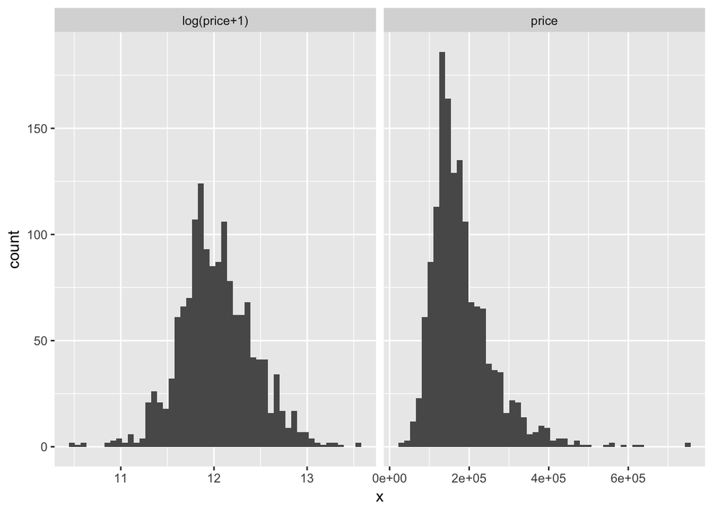

```r
# get data frame of SalePrice and log(SalePrice + 1) for plotting
df <- rbind(data.frame(version="log(price+1)",x=log(SalePrice + 1)),
            data.frame(version="price",x=SalePrice))
# version is name of what you want to call it

ggplot(data=df) +
  facet_wrap(~version,ncol=2,scales="free_x") +
  geom_histogram(aes(x=x), bins = 50)
```

We therefore transform the target value applying log

```r
# Log transform the target for official scoring
SalePrice <- log1p(SalePrice)
```

Skew the numeric variables

```r
column_types = sapply(names(all), function(x){class(all[[x]])})
numeric_columns =names(column_types[column_types != "factor"])

# skew of each variable
skew = sapply(numeric_columns,function(x){skewness(all[[x]],na.rm = T)})

# transform all variables above a threshold skewness.
skew = skew[skew > 0.75]
for(x in names(skew)) {
    all[[x]] = log(all[[x]] + 1)
}
```

Add the dummy variables to the existing data frame

```r
all = cbind(all[numeric_vars], categorical_1_hot)
```

** UNMERGE DATA **

Now lets unmerge the data frame so we can analyze the dependency of SalePrice

```r
X_train = all[1:nrow(trainingH),] # training data
X_test = all[(nrow(trainingH) + 1):nrow(all),] # test data
X_train = cbind(SalePrice, X_train) # adding SalePrice to training
```

** Remove Some Outliers **

GrLivArea

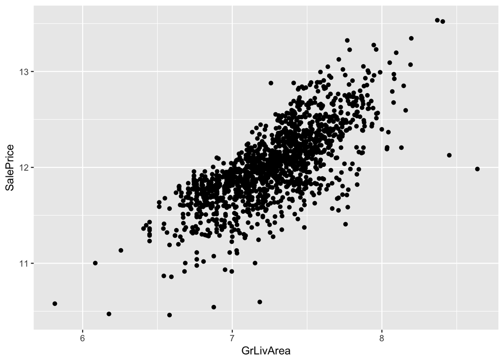

```r
# read the kaggle info and it says to remove outliers greater than 4000
ggplot(data=X_train) +
  geom_point(mapping=aes(x=GrLivArea, y=SalePrice))
```

```r
# view those outliers
X_train %>%
  arrange(desc(GrLivArea)) %>%
  head(2)

# get rid of outliers
X_train <- X_train[X_train$GrLivArea<8.45, ]
```

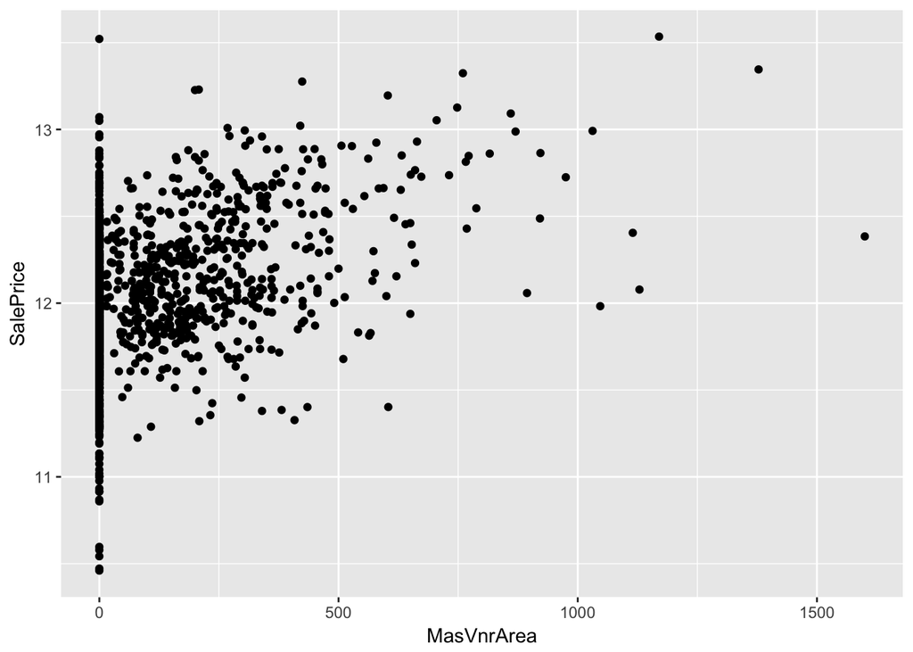

```r
# MasVnrArea
ggplot(data=X_train) +
  geom_point(mapping=aes(x=MasVnrArea, y=SalePrice))
```

** THE MODEL THIS IS THE PROFESSOR’S CODE FROM OUR MACHINE LEARNING COURSE** Includes a little modification

```r
# I found this function, that is worth to save for future ocasions.
splitdf = function(dataframe, seed=NULL) {
  if (!is.null(seed)) set.seed(seed)
    index = 1:nrow(dataframe)
    trainindex = sample(index, trunc(length(index)/1.5))
    trainset = dataframe[trainindex, ]
    testset = dataframe[-trainindex, ]
    list(trainset=trainset,testset=testset)
}

splits = splitdf(X_train, seed=1)
training = splits$trainset
validation = splits$testset
```

## Chi-Squared

We will compute the CHI SQ to check the level of association between variables

```r
weights_chi = data.frame(chi.squared(SalePrice~., X_train))
weights_chi$feature = rownames(weights_chi)
weights_chi[order(weights_chi$attr_importance, decreasing = TRUE),]
```

```
##                       attr_importance               feature
## ExterQual.TA               0.65713263          ExterQual.TA
## FullBath                   0.64280287              FullBath
## ExterQual.Gd               0.59439302          ExterQual.Gd
## KitchenQual.TA             0.58945408        KitchenQual.TA
## Foundation.PConc           0.56201963      Foundation.PConc
## BsmtQual.TA                0.53672445           BsmtQual.TA
## Fireplaces                 0.52381098            Fireplaces
## FireplaceQu.None           0.52381098      FireplaceQu.None
## GarageFinish.Unf           0.51303461      GarageFinish.Unf
## KitchenQual.Gd             0.51130015        KitchenQual.Gd
## OverallQual                0.50986381           OverallQual
## GarageCars                 0.48629207            GarageCars
## BsmtQual.Gd                0.48402672           BsmtQual.Gd
## GarageType.Attchd          0.48343932     GarageType.Attchd
## YearBuilt                  0.48036106             YearBuilt
## HeatingQC.Ex               0.47634875          HeatingQC.Ex
## BsmtQual.Ex                0.46759589           BsmtQual.Ex
## GarageType.Detchd          0.44872916     GarageType.Detchd
## BsmtFinType1.GLQ           0.44299440      BsmtFinType1.GLQ
## GarageYrBlt                0.43608285           GarageYrBlt
## KitchenQual.Ex             0.43438610        KitchenQual.Ex
## GrLivArea                  0.43048150             GrLivArea
## GarageArea                 0.42166334            GarageArea
## GarageFinish.Fin           0.40955992      GarageFinish.Fin
## YearRemodAdd               0.40799451          YearRemodAdd
## Foundation.CBlock          0.40533464     Foundation.CBlock
## MSZoning.RM                0.39820560           MSZoning.RM
## Exterior2nd.VinylSd        0.38444166   Exterior2nd.VinylSd
## GarageQual.TA              0.38250488         GarageQual.TA
## GarageCond.TA              0.38148645         GarageCond.TA
## Exterior1st.VinylSd        0.38034863   Exterior1st.VinylSd
## TotalBsmtSF                0.37392006           TotalBsmtSF
## OpenPorchSF                0.37294495           OpenPorchSF
## MasVnrType.None            0.36983017       MasVnrType.None
## HeatingQC.TA               0.36484827          HeatingQC.TA
## HalfBath                   0.36441918              HalfBath
## MSSubClass                 0.36162901            MSSubClass
## Neighborhood.NridgHt       0.35567180  Neighborhood.NridgHt
## X1stFlrSF                  0.35143661             X1stFlrSF
```

[output cut: 246 more lines]

```
## MiscFeature.Shed           0.00000000      MiscFeature.Shed
## MiscFeature.TenC           0.00000000      MiscFeature.TenC
## MiscFeature.None           0.00000000      MiscFeature.None
## SaleType.COD               0.00000000          SaleType.COD
## SaleType.Con               0.00000000          SaleType.Con
## SaleType.ConLD             0.00000000        SaleType.ConLD
## SaleType.ConLI             0.00000000        SaleType.ConLI
## SaleType.ConLw             0.00000000        SaleType.ConLw
## SaleType.CWD               0.00000000          SaleType.CWD
## SaleType.Oth               0.00000000          SaleType.Oth
## SaleCondition.Abnorml      0.00000000 SaleCondition.Abnorml
## SaleCondition.AdjLand      0.00000000 SaleCondition.AdjLand
## SaleCondition.Alloca       0.00000000  SaleCondition.Alloca
## SaleCondition.Family       0.00000000  SaleCondition.Family
## SaleCondition.Normal       0.00000000  SaleCondition.Normal
```

```r
chi_squared_features = weights_chi$feature[weights_chi$attr_importance >= 0.15]
```

```r
training = training[append(chi_squared_features, "SalePrice")]
validation = validation[append(chi_squared_features, "SalePrice")]
```

### Lasso Regresion

EVALUTION Plot the RMSE for the different lambda values and Explain the results.

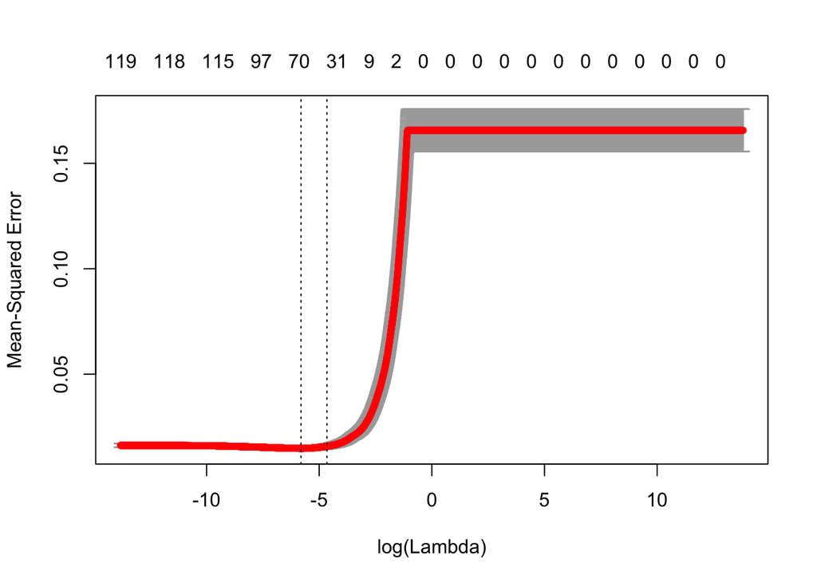

```r
lambdas = 10^seq(-6, 6, by = 0.001)
#alphas = 10^seq(0, 1, by = 0.01) # didnt use


lasso.cv_fit = cv.glmnet(x = data.matrix(training[,-ncol(training)]), y=training$SalePrice, alpha = 1, lambda = lambdas)
plot(lasso.cv_fit)
```

Select the best lambda form the CV model, use it to predict the target value of the validation set and evaluate the results (in terms of RMSE)

```r
bestlam = lasso.cv_fit$lambda.min
paste("Best Lambda value from CV=", bestlam)
```

```
## [1] "Best Lambda value from CV= 0.00300607630262823"
```

```r
lasso.mod = glmnet(x = data.matrix(training[,-ncol(training)]), y=training$SalePrice, alpha = 1, lambda = lambdas)
lasso.pred=predict(lasso.mod, s=bestlam, data.matrix(validation[,-ncol(validation)]))
paste("RMSE for lambda ", bestlam, " = ", sqrt(mean((lasso.pred - validation$SalePrice)^2)))
```

```
## [1] "RMSE for lambda  0.00300607630262823  =  0.114896160173016"
```

Select the λ1se value from the CV model to predict on the validation set

```r
lam1se = lasso.cv_fit$lambda.1se
paste("Lambda 1se value from CV=", lam1se)
```

```
## [1] "Lambda 1se value from CV= 0.00948418463300897"
```

```r
lasso.mod = glmnet(x = data.matrix(training[,-ncol(training)]), y=training$SalePrice, alpha = 1, lambda = lambdas)
lasso.pred=predict(lasso.mod, s=lam1se, data.matrix(validation[,-ncol(validation)]))
paste("RMSE for lambda ", lam1se, " = ", sqrt(mean((lasso.pred - validation$SalePrice)^2)))
```

```
## [1] "RMSE for lambda  0.00948418463300897  =  0.120045734437464"
```

Predictions against the actual values

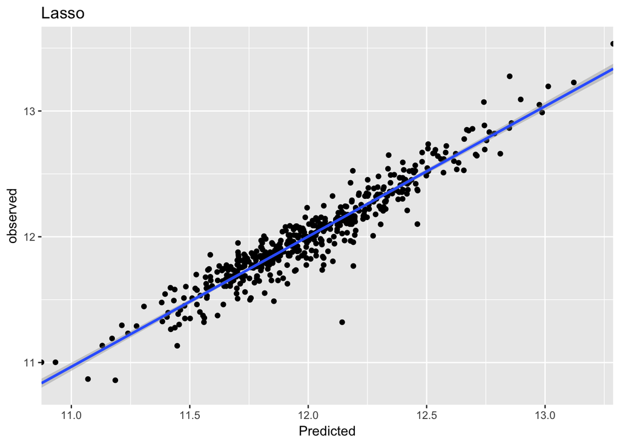

```r
# Plot important coefficients
my_data=as.data.frame(cbind(predicted=lasso.pred,observed=validation$SalePrice))

ggplot(my_data,aes(my_data["1"],observed))+
  geom_point()+geom_smooth(method="lm")+
  scale_x_continuous(expand = c(0,0)) +
  labs(x="Predicted") +
  ggtitle('Lasso')
```

Variable importance

```r
# Print, plot variable importance
imp = varImp(lasso.mod, lambda = bestlam)
names = rownames(imp)[order(imp$Overall, decreasing=TRUE)]
importance = imp[names,]

data.frame(row.names = names, importance)
```

```
##                         importance
## GrLivArea             3.854111e-01
## Neighborhood.IDOTRR   9.723464e-02
## Neighborhood.StoneBr  8.174567e-02
## LotArea               7.178420e-02
## SaleType.New          6.859959e-02
## OverallQual           6.480074e-02
## Neighborhood.OldTown  6.326622e-02
## ExterCond.Fa          6.226107e-02
## CentralAir            5.925416e-02
## Neighborhood.NoRidge  5.877143e-02
## Condition1.Artery     5.554859e-02
## Neighborhood.BrDale   5.242977e-02
## MSZoning.FV           5.146647e-02
## Neighborhood.MeadowV  4.764205e-02
## BldgType.Duplex       4.747084e-02
## OverallCond           4.013606e-02
## KitchenQual.Ex        3.897645e-02
## GarageCars            3.683027e-02
## BsmtExposure.Gd       3.662037e-02
## Neighborhood.Edwards  3.193720e-02
## BsmtCond.Fa           3.096349e-02
## Neighborhood.NridgHt  2.830214e-02
## Foundation.PConc      2.726291e-02
## Foundation.BrkTil     2.608626e-02
## LotConfig.CulDSac     2.595038e-02
## BsmtQual.Ex           2.495999e-02
## Exterior1st.Wd Sdng   2.427747e-02
## HeatingQC.Ex          2.240258e-02
## PavedDrive.Y          2.208715e-02
## BsmtFullBath          2.160039e-02
## FireplaceQu.Gd        1.964435e-02
## Neighborhood.Sawyer   1.876844e-02
## Fireplaces            1.703035e-02
## GarageQual.TA         1.525754e-02
## Neighborhood.BrkSide  1.194773e-02
## Neighborhood.NWAmes   1.109937e-02
## FullBath              1.108149e-02
## MSZoning.RL           9.846028e-03
## BsmtQual.TA           9.677611e-03
```

[output cut: 73 more lines]

```
## FireplaceQu.Ex        0.000000e+00
## FireplaceQu.TA        0.000000e+00
## FireplaceQu.None      0.000000e+00
## GarageType.Attchd     0.000000e+00
## GarageType.Detchd     0.000000e+00
## GarageType.None       0.000000e+00
## GarageFinish.RFn      0.000000e+00
## GarageFinish.None     0.000000e+00
## GarageQual.None       0.000000e+00
## GarageCond.Fa         0.000000e+00
## GarageCond.None       0.000000e+00
## PavedDrive.N          0.000000e+00
## Fence.MnPrv           0.000000e+00
## SaleType.WD           0.000000e+00
## SaleCondition.Partial 0.000000e+00
```

|PREDICTION FOR THE TEST DATA|

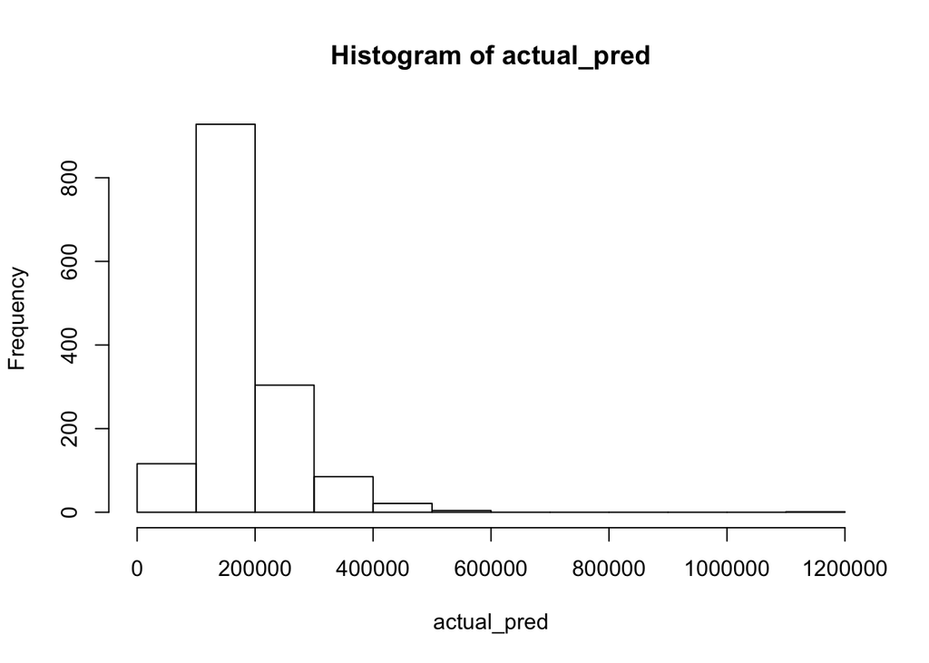

```r
log_prediction = predict(lasso.cv_fit,  s=lasso.cv_fit$lambda.min, newx = data.matrix(X_test[chi_squared_features]))

actual_pred = exp(log_prediction)-1

hist(actual_pred)
```

```r
submit = data.frame(Id= X_test$Id,SalePrice=actual_pred)
colnames(submit) =c("Id", "SalePrice")

submit$SalePrice[is.na(submit$SalePrice)] = 0
replace_value_for_na = sum(na.omit(submit$SalePrice))/(nrow(submit) - sum(submit$SalePrice == 0))
submit$SalePrice[submit$SalePrice == 0] = replace_value_for_na

write.csv(submit,file="lasso_cris_diego_best.csv",row.names=F)
```

Using this code, we were able to get a RMSE for the House Prices Kaggle Competion of 0.12115. We can further improve it but this was the final version we submitted.